# DASC user guide

# 7 Analysis on entire Stanford Dataset

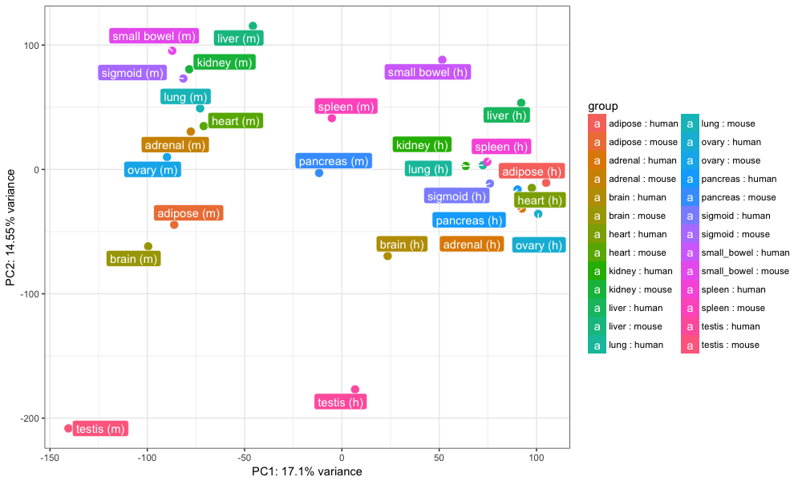

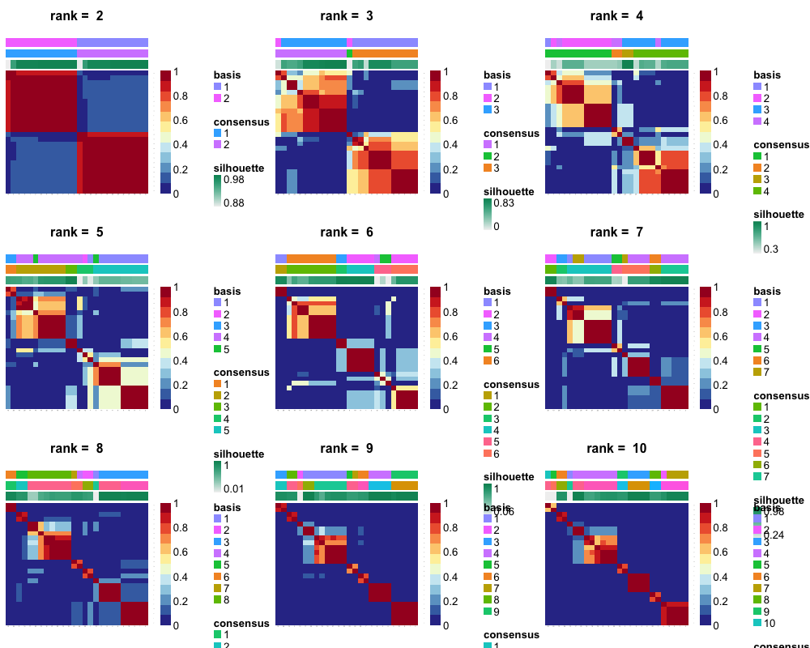

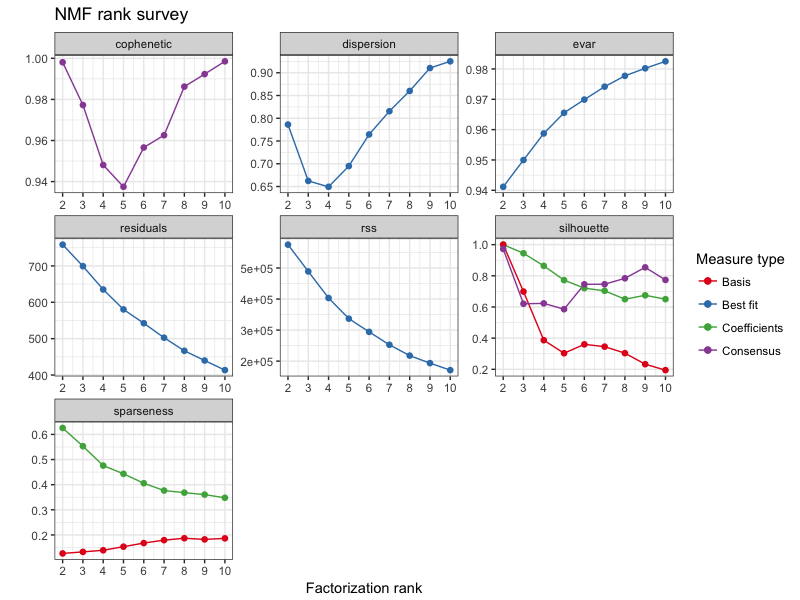

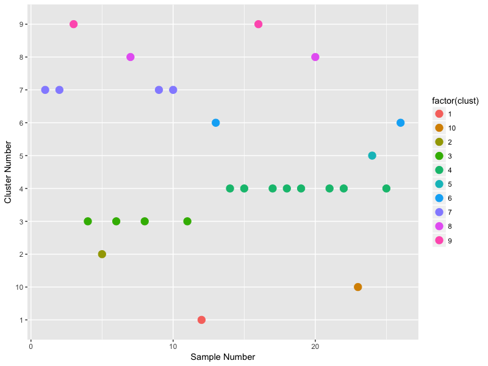

```r
## not running this part of the code for building package
## Using entire dataset
rawCounts <- stanfordData$rawCounts
metadata <- stanfordData$metadata
dds <- DESeqDataSetFromMatrix(rawCounts, metadata, design = ~ species+tissue)
dds <- estimateSizeFactors(dds)
dat <- counts(dds, normalized = TRUE)
lognormalizedCounts <- log2(dat + 1)

## PCA Plot
rld.dds <- rlog(dds)
pcaplot(rld.dds, intgroup=c("tissue","species"), ntop = nrow(rld.dds),
        pcX = 1, pcY = 2)

## Running DASC
res <- convex_batch(edata = dat, pdata = metadata,
                        factor = metadata$tissue, method = 'ama', type = 3,
                        lambda = 1, rank = 2:10, nrun = 100,
                        annotation = 'Stanford Dataset')
## Consensus plot
consensusmap(res)

## Residual plot
plot(res)

## Clustering samples based on batches
sample.clust <- data.frame(sample.name = colnames(lognormalizedCounts),
                            clust = as.vector(predict(res$fit$`10`)),
                            batch = metadata$seqBatch)
ggplot(data = sample.clust, aes(x=c(1:26), y=clust, color=factor(clust))) +
    geom_point(size = 4) + xlab("Sample Number") + ylab("Cluster Number")
```

Based on the PCA plot, we see the PC1 captures the differences based on species. Based on `consensusmap` plot and Cophenetic & dispersion values, there are 10 batches in the dataset. Our results show that the batches are not only due to platform but due other reason like differences in the date and the time of library preparation and sequencing of the samples. Another important observation, is that at rank equal to 2, we observe entire dataset to cluster based on speicies.